# IODS course project

```r
summary(Boston$dis)
```

```
##    Min. 1st Qu.  Median    Mean 3rd Qu.    Max.
##   1.130   2.100   3.207   3.795   5.188  12.130
```

Nest I create a categorical variable of the crime rate. I use the quantiles as the break points in the categorical variable.

```r
#save the scaled crim as scaled_crim
scaled_crim <- boston_scaled$crim
# create a quantile vector of scaled_crim
bins <- quantile(scaled_crim)
#create a categorical variable 'crime'
crime <- cut(scaled_crim, breaks = bins, include.lowest = TRUE, labels = c("low", "med_low", "med_high", "high"))
#see the categorical variable of crime
table(crime)
```

```
## crime
##      low  med_low med_high     high
##      127      126      126      127
```

Now I delete the old, numerical variable “crim” from the dataset and save the new one instead. I make sure everything worked OK by checking the names of the dataset.

```r
#install and use the package
install.packages("dplyr", repos="http://cran.rstudio.com/")
library(dplyr)
```

```r
#remove original crim from the dataset
boston_scaled <- dplyr::select(boston_scaled, -crim)
#add the new categorical value to scaled data
boston_scaled <- data.frame(boston_scaled, crime)
#check that dataset is ok
names(boston_scaled)
```

```
##  [1] "zn"      "indus"   "chas"    "nox"     "rm"      "age"     "dis"
##  [8] "rad"     "tax"     "ptratio" "black"   "lstat"   "medv"    "crime"
```

Now I divide my dataset to a training set and a testing set. Splitting the original data to test and train sets allows us to check how well our model works. I’ll select randomly 80 % of the rows to my training set.

```r
#number of rows in the Boston dataset
n <- nrow(boston_scaled)
#choose randomly 80% of the rows
ind <- sample(n,  size = n * 0.8)
#create train set
train <- boston_scaled[ind,]
#create test set
test <- boston_scaled[-ind,]
str(train)
```

```
## 'data.frame':    404 obs. of  14 variables:
##  $ zn     : num  -0.487 -0.487 -0.487 -0.487 -0.487 ...
##  $ indus  : num  1.015 -0.0797 -0.8668 1.5674 -0.0797 ...
##  $ chas   : num  -0.272 -0.272 -0.272 -0.272 3.665 ...
##  $ nox    : num  0.866 -0.567 -0.343 0.598 -0.567 ...
##  $ rm     : num  -0.748 0.129 -0.592 -0.922 -0.462 ...
##  $ age    : num  -0.724 -1.289 -0.791 0.928 0.836 ...
##  $ dis    : num  -0.346 0.0714 0.682 -0.862 0.039 ...
##  $ rad    : num  1.66 -0.637 -0.522 -0.637 -0.637 ...
##  $ tax    : num  1.529 -0.779 -1.093 0.171 -0.779 ...
##  $ ptratio: num  0.8058 0.0667 0.8058 1.2677 0.0667 ...
##  $ black  : num  -0.244 0.319 0.441 0.441 0.401 ...
##  $ lstat  : num  0.207 -0.458 -0.4 0.796 0.647 ...
##  $ medv   : num  -0.2863 0.6053 -0.3298 -0.8952 -0.0906 ...
##  $ crime  : Factor w/ 4 levels "low","med_low",..: 3 2 1 3 2 2 3 4 2 4 ...
```

```r
str(test)
```

```
## 'data.frame':    102 obs. of  14 variables:
##  $ zn     : num  0.2845 -0.4872 0.0487 0.0487 0.0487 ...
##  $ indus  : num  -1.287 -1.306 -0.476 -0.476 -0.476 ...
##  $ chas   : num  -0.272 -0.272 -0.272 -0.272 -0.272 ...
##  $ nox    : num  -0.144 -0.834 -0.265 -0.265 -0.265 ...
##  $ rm     : num  0.413 1.227 -0.16 -0.93 -0.399 ...
##  $ age    : num  -0.12 -0.511 0.978 1.116 0.615 ...
##  $ dis    : num  0.14 1.08 1.02 1.09 1.33 ...
##  $ rad    : num  -0.982 -0.752 -0.522 -0.522 -0.522 ...
##  $ tax    : num  -0.666 -1.105 -0.577 -0.577 -0.577 ...
##  $ ptratio: num  -1.458 0.113 -1.504 -1.504 -1.504 ...
##  $ black  : num  0.441 0.441 0.441 0.328 0.329 ...
##  $ lstat  : num  -1.074 -1.025 0.91 2.419 0.623 ...
##  $ medv   : num  0.16 1.486 0.497 -0.656 -0.395 ...
##  $ crime  : Factor w/ 4 levels "low","med_low",..: 1 1 2 2 2 2 2 3 3 3 ...
```

Next I fit the linear discriminant analysis on the training set. Linear discriminant analysis is a classification (and dimension reduction) method. It finds the (linear) combination of the variables that separate the target variable classes. I use the categorical crime rate as the target variable and all the other variables in the dataset as predictor variables.

```r
#linear discriminant analysis
lda.fit <- lda(crime ~ ., data = train)
#print the lda.fit object
lda.fit
```

```
## Call:
## lda(crime ~ ., data = train)
##
## Prior probabilities of groups:
##       low   med_low  med_high      high
## 0.2425743 0.2475248 0.2648515 0.2450495
##
## Group means:
##                   zn      indus         chas        nox          rm
## low       0.92923664 -0.9358629 -0.111631099 -0.8860783  0.43760340
## med_low  -0.06018391 -0.3609550  0.003267949 -0.6143207 -0.11704011
## med_high -0.37343545  0.1934789  0.169214884  0.3766160  0.08733862
## high     -0.48724019  1.0171737 -0.113254311  1.0700233 -0.38746628
##                 age        dis        rad        tax    ptratio
## low      -0.8878600  0.8931318 -0.6724882 -0.7116001 -0.4743594
## med_low  -0.4351828  0.3741252 -0.5454537 -0.4955416 -0.0459751
## med_high  0.4202244 -0.3742359 -0.4130044 -0.3056192 -0.3010678
## high      0.8239330 -0.8527276  1.6375616  1.5136504  0.7801170
##                black       lstat        medv
## low       0.37763316 -0.77610967  0.52665755
## med_low   0.31343678 -0.21182610  0.03133526
## med_high  0.09632735  0.01178158  0.17578646
## high     -0.79828017  0.90551393 -0.73952552
##
## Coefficients of linear discriminants:
##                  LD1          LD2         LD3
## zn       0.113505618  0.580227191 -0.98950937
## indus    0.025480373 -0.398248279  0.24369372
## chas    -0.033502001 -0.007842191  0.07435583
## nox      0.431806232 -0.756570124 -1.21963219
## rm       0.060282422 -0.033935853 -0.17867741
## age      0.292904522 -0.377151288 -0.25639099
## dis     -0.065015586 -0.262941375  0.02122009
## rad      3.156462201  0.863098087 -0.12823505
## tax      0.005096174  0.141260766  0.49217207
## ptratio  0.130940015  0.024123567 -0.20621159
## black   -0.104941161  0.012398968  0.08900008
## lstat    0.176481798 -0.130561981  0.32984740
## medv     0.039152152 -0.398252906 -0.20172589
##
## Proportion of trace:
##    LD1    LD2    LD3
## 0.9498 0.0389 0.0113
```

In the first row, we see the prior probabilities of groups: they are roughly 25 % for each. Then we have the group means which seem to differ between the groups. Then we have the coefficients of linear discriminants and the proportion of trace which gives the percentage separation achieved by each discriminant function. We see that our first discriminant function explains the between group variance much better than the next two functions.

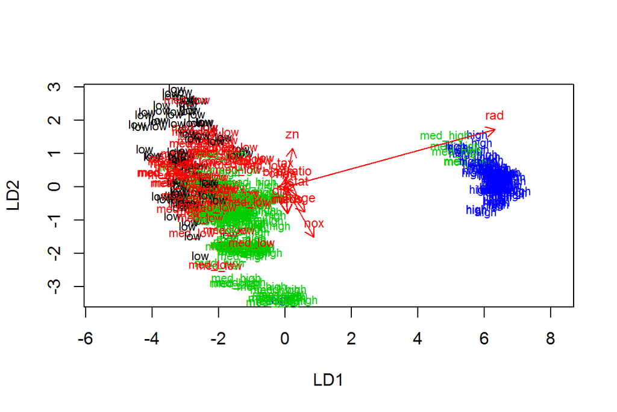

```r
#the function for lda biplot arrows
lda.arrows <- function(x, myscale = 1, arrow_heads = 0.1, color = "red", tex = 0.75, choices = c(1,2)){
  heads <- coef(x)
  arrows(x0 = 0, y0 = 0,
         x1 = myscale * heads[,choices[1]],
         y1 = myscale * heads[,choices[2]], col=color, length = arrow_heads)
  text(myscale * heads[,choices], labels = row.names(heads),
       cex = tex, col=color, pos=3)
}

# target classes as numeric
classes <- as.numeric(train$crime)

# plot the lda results
plot(lda.fit, dimen = 2, col=classes, pch=classes)
lda.arrows(lda.fit, myscale = 2)
```

Next I test how well my model predicts the classes for the test set.

```r
#save the correct classes from test data
correct_classes <- test$crime
#remove the crime variable from test data
test <- dplyr::select(test, -crime)
# predict classes with test data and save them to the
lda.pred <- predict(lda.fit, newdata = test)
# cross tabulate the results
table(correct = correct_classes, predicted = lda.pred$class) %>% addmargins()
```

```
##           predicted
## correct    low med_low med_high high Sum
##   low       19       9        1    0  29
##   med_low    1      15       10    0  26
##   med_high   0       4       14    1  19
##   high       0       0        0   28  28
##   Sum       20      28       25   29 102
```